# Moringa Module III Project

Daniel

7/3/2021

*Objectives*

The objective of the project is to carry out exploratory data analysis to understand what factors that can possibly make someone click on an add

*Metrics of Success*

To use various statistical techniques to find the mean, median, standard deviation, range correlation to find what factors might have led to clicking to an add.

*ADVERTISING COMPANY DATASET*

*loading the dataset*

previewing the first 6 items of our dataset

```
##   Daily.Time.Spent.on.Site Age Area.Income Daily.Internet.Usage
## 1                    68.95  35    61833.90               256.09
## 2                    80.23  31    68441.85               193.77
## 3                    69.47  26    59785.94               236.50
## 4                    74.15  29    54806.18               245.89
## 5                    68.37  35    73889.99               225.58
## 6                    59.99  23    59761.56               226.74
##                           Ad.Topic.Line           City Male    Country
## 1    Cloned 5thgeneration orchestration    Wrightburgh    0    Tunisia
## 2    Monitored national standardization      West Jodi    1      Nauru
## 3      Organic bottom-line service-desk       Davidton    0 San Marino
## 4 Triple-buffered reciprocal time-frame West Terrifurt    1      Italy
## 5         Robust logistical utilization   South Manuel    0    Iceland
## 6       Sharable client-driven software      Jamieberg    1     Norway
##             Timestamp Clicked.on.Ad
## 1 2016-03-27 00:53:11             0
## 2 2016-04-04 01:39:02             0
## 3 2016-03-13 20:35:42             0
## 4 2016-01-10 02:31:19             0
## 5 2016-06-03 03:36:18             0
## 6 2016-05-19 14:30:17             0
```

```r
str(advertising)
```

```
## 'data.frame':    1000 obs. of  10 variables:
##  $ Daily.Time.Spent.on.Site: num  69 80.2 69.5 74.2 68.4 ...
##  $ Age                     : int  35 31 26 29 35 23 33 48 30 20 ...
##  $ Area.Income             : num  61834 68442 59786 54806 73890 ...
##  $ Daily.Internet.Usage    : num  256 194 236 246 226 ...
##  $ Ad.Topic.Line           : chr  "Cloned 5thgeneration orchestration" "Monitored national standardization" "Organic bottom-line service-desk" "Triple-buffered reciprocal time-frame" ...
##  $ City                    : chr  "Wrightburgh" "West Jodi" "Davidton" "West Terrifurt" ...
##  $ Male                    : int  0 1 0 1 0 1 0 1 1 1 ...
##  $ Country                 : chr  "Tunisia" "Nauru" "San Marino" "Italy" ...
##  $ Timestamp               : chr  "2016-03-27 00:53:11" "2016-04-04 01:39:02" "2016-03-13 20:35:42" "2016-01-10 02:31:19" ...
##  $ Clicked.on.Ad           : int  0 0 0 0 0 0 0 1 0 0 ...
```

Checking the dataset description

```r
tail(advertising)
```

```
##      Daily.Time.Spent.on.Site Age Area.Income Daily.Internet.Usage
## 995                     43.70  28    63126.96               173.01
## 996                     72.97  30    71384.57               208.58
## 997                     51.30  45    67782.17               134.42
## 998                     51.63  51    42415.72               120.37
## 999                     55.55  19    41920.79               187.95
## 1000                    45.01  26    29875.80               178.35
##                             Ad.Topic.Line          City Male
## 995         Front-line bifurcated ability  Nicholasland    0
## 996         Fundamental modular algorithm     Duffystad    1
## 997       Grass-roots cohesive monitoring   New Darlene    1
## 998          Expanded intangible solution South Jessica    1
## 999  Proactive bandwidth-monitored policy   West Steven    0
## 1000      Virtual 5thgeneration emulation   Ronniemouth    0
##                     Country           Timestamp Clicked.on.Ad
## 995                 Mayotte 2016-04-04 03:57:48             1
## 996                 Lebanon 2016-02-11 21:49:00             1
## 997  Bosnia and Herzegovina 2016-04-22 02:07:01             1
## 998                Mongolia 2016-02-01 17:24:57             1
## 999               Guatemala 2016-03-24 02:35:54             0
## 1000                 Brazil 2016-06-03 21:43:21             1
```

*checking dataset dimensions*

```r
dim(advertising)
```

```
## [1] 1000   10
```

##Data cleaning *Checking for null values*

```r
colSums(is.na(advertising))
```

```
## Daily.Time.Spent.on.Site                      Age              Area.Income
##                        0                        0                        0
##     Daily.Internet.Usage            Ad.Topic.Line                     City
##                        0                        0                        0
##                     Male                  Country                Timestamp
##                        0                        0                        0
##            Clicked.on.Ad
##                        0
```

*checking the list of complete columns in our dataset*

```r
advertising[!complete.cases(advertising),]
```

```
##  [1] Daily.Time.Spent.on.Site Age                      Area.Income
##  [4] Daily.Internet.Usage     Ad.Topic.Line            City
##  [7] Male                     Country                  Timestamp
## [10] Clicked.on.Ad
## <0 rows> (or 0-length row.names)
```

thus our dataset doesn’t have null values

*checking for duplicates in our dataset*

```r
advertising[duplicated(advertising),]
```

```
##  [1] Daily.Time.Spent.on.Site Age                      Area.Income
##  [4] Daily.Internet.Usage     Ad.Topic.Line            City
##  [7] Male                     Country                  Timestamp
## [10] Clicked.on.Ad
## <0 rows> (or 0-length row.names)
```

thus our data set did not contain duplicated data

*Checking the presence of outliers in the dataset*

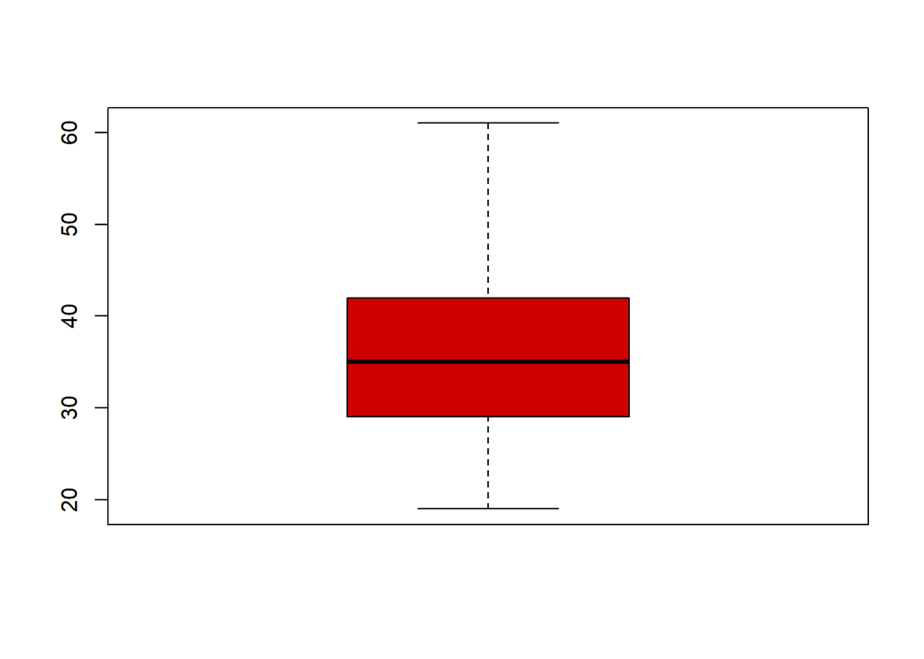

```r
boxplot(advertising$Age ,col="red3")
```

thus no outliers on the Age column

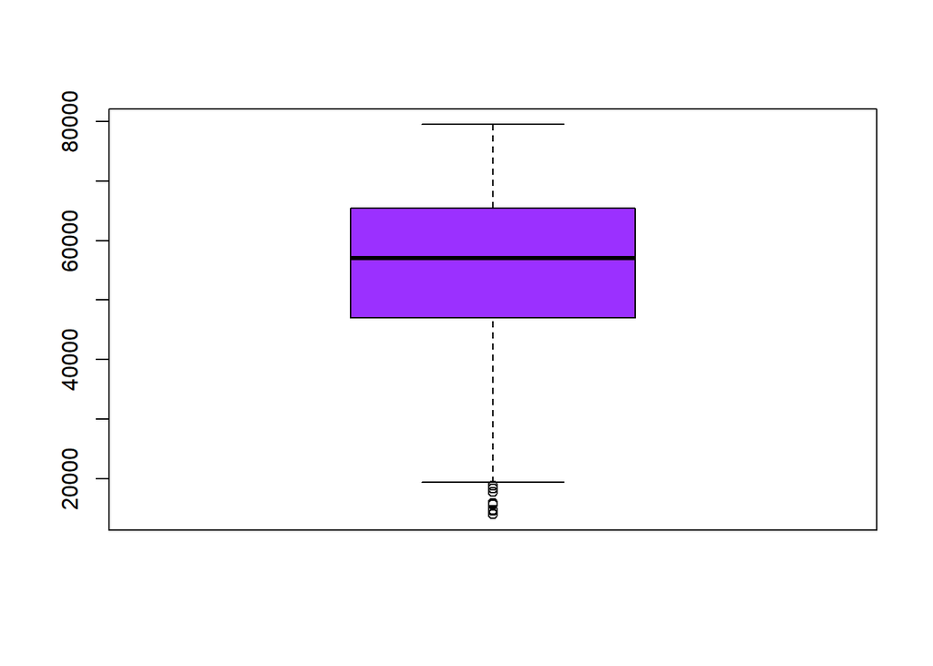

```r
boxplot(advertising$Area.Income, col=" purple1")
```

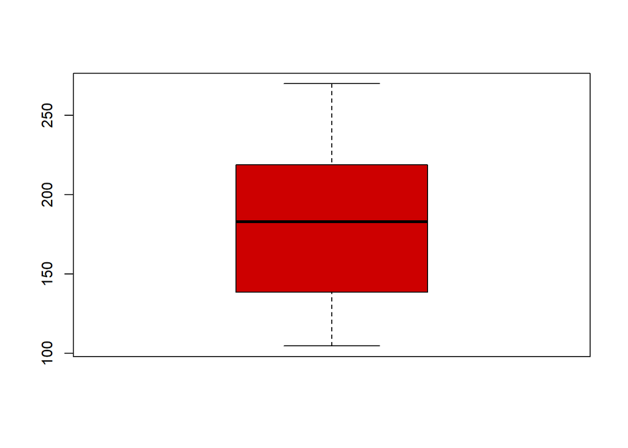

```r
boxplot(advertising$Daily.Internet.Usage, col = "red3")
```

the column daily.internet usage didn’t have any outliers

##Exploratory Data Analysis

*Measures of central tendency*

calculating the mean of our categorical columns

```r
mean_Age=mean(advertising$Age)
mean_Age
```

```
## [1] 36.009
```

```r
mean_time=mean(advertising$Daily.Time.Spent.on.Site)
mean_time
```

```
## [1] 65.0002
```

```r
mean_area_income=mean(advertising$Area.Income)
mean_area_income
```

```
## [1] 55000
```

```r
mean_internet_usage=mean(advertising$Daily.Internet.Usage)
mean_internet_usage
```

```
## [1] 180.0001
```

calculating the median of the categorical columns

```r
median(advertising$Daily.Time.Spent.on.Site)
```

```
## [1] 68.215
```

```r
median(advertising$Age)
```

```
## [1] 35
```

```r
median(advertising$Area.Income)
```

```
## [1] 57012.3
```

```r
median(advertising$Daily.Internet.Usage)
```

```
## [1] 183.13
```

```r
median(advertising$Clicked.on.Ad)
```

```
## [1] 0.5
```

calculating the range

```r
range(advertising$Daily.Time.Spent.on.Site)
```

```
## [1] 32.60 91.43
```

```r
range(advertising$Age)
```

```
## [1] 19 61
```

```r
range(advertising$Area.Income)
```

```
## [1] 13996.5 79484.8
```

```r
range(advertising$Daily.Internet.Usage)
```

```
## [1] 104.78 269.96
```

```r
range(advertising$Clicked.on.Ad)
```

```
## [1] 0 1
```

finding the standard devition

```r
sd(advertising$Daily.Time.Spent.on.Site)
```

```
## [1] 15.85361
```

```r
sd(advertising$Age)
```

```
## [1] 8.785562
```

```r
sd(advertising$Area.Income)
```

```
## [1] 13414.63
```

```r
sd(advertising$Daily.Internet.Usage)
```

```
## [1] 43.90234
```

```r
sd(advertising$Clicked.on.Ad)
```

```
## [1] 0.5002502
```

```r
#checking for quantiles in each columns
quantile(advertising$Daily.Time.Spent.on.Site)
```

```
##      0%     25%     50%     75%    100%
## 32.6000 51.3600 68.2150 78.5475 91.4300
```

```r
quantile(advertising$Age)
```

```
##   0%  25%  50%  75% 100%
##   19   29   35   42   61
```

```r
quantile(advertising$Area.Income)
```

```
##       0%      25%      50%      75%     100%
## 13996.50 47031.80 57012.30 65470.64 79484.80
```

```r
quantile(advertising$Daily.Internet.Usage)
```

```
##       0%      25%      50%      75%     100%
## 104.7800 138.8300 183.1300 218.7925 269.9600
```

```r
quantile(advertising$Clicked.on.Ad)
```

```
##   0%  25%  50%  75% 100%
##  0.0  0.0  0.5  1.0  1.0
```

*Numerical*

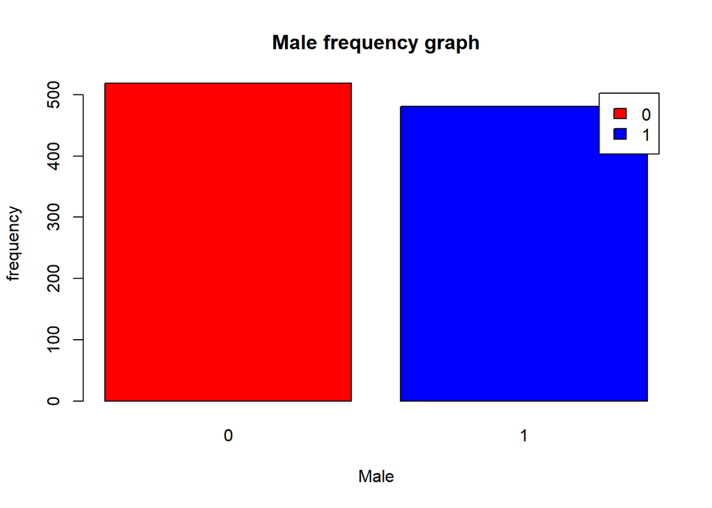

```r
count_male<- table(advertising$Male)
barplot(count_male,main="Male frequency graph", xlab="Male",ylab= "frequency",legend=row.names(count_male),col=c("red","blue"))
```

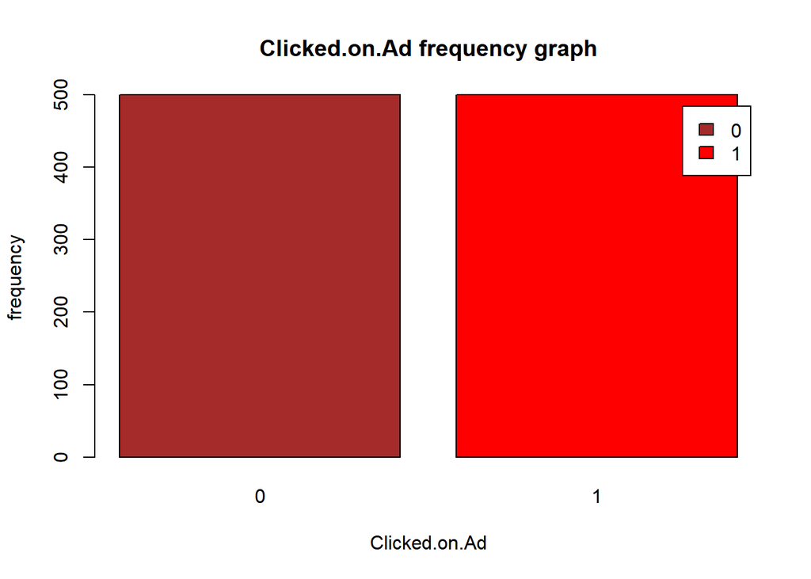

```r
count_clicked<- table(advertising$Clicked.on.Ad)
barplot(count_clicked,main="Clicked.on.Ad frequency graph", xlab="Clicked.on.Ad",ylab= "frequency",legend=row.names(count_clicked),col=c("brown","red"))
```

From the figure we can see that the number of clicks on the ad were equal to the number of people who didn’t click on the add

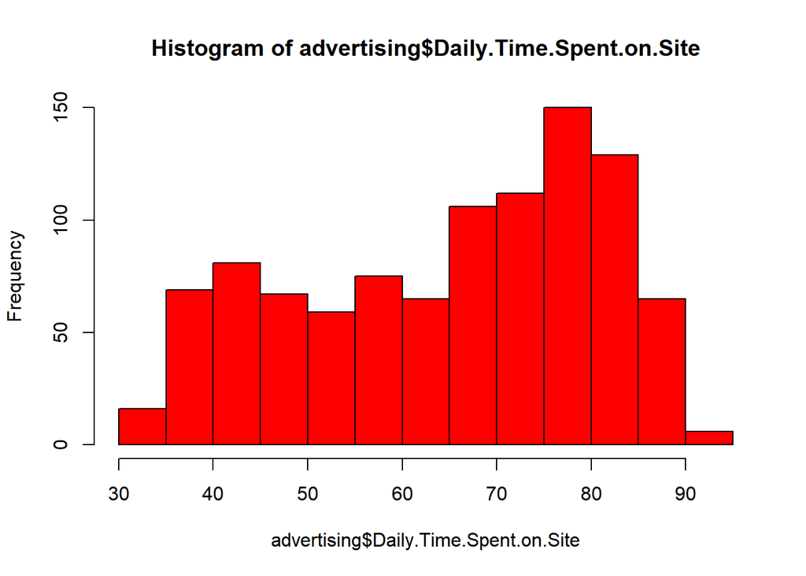

```r
#Frequency histogram to show daily time spend on site
hist(advertising$Daily.Time.Spent.on.Site,col=c("red"))
```

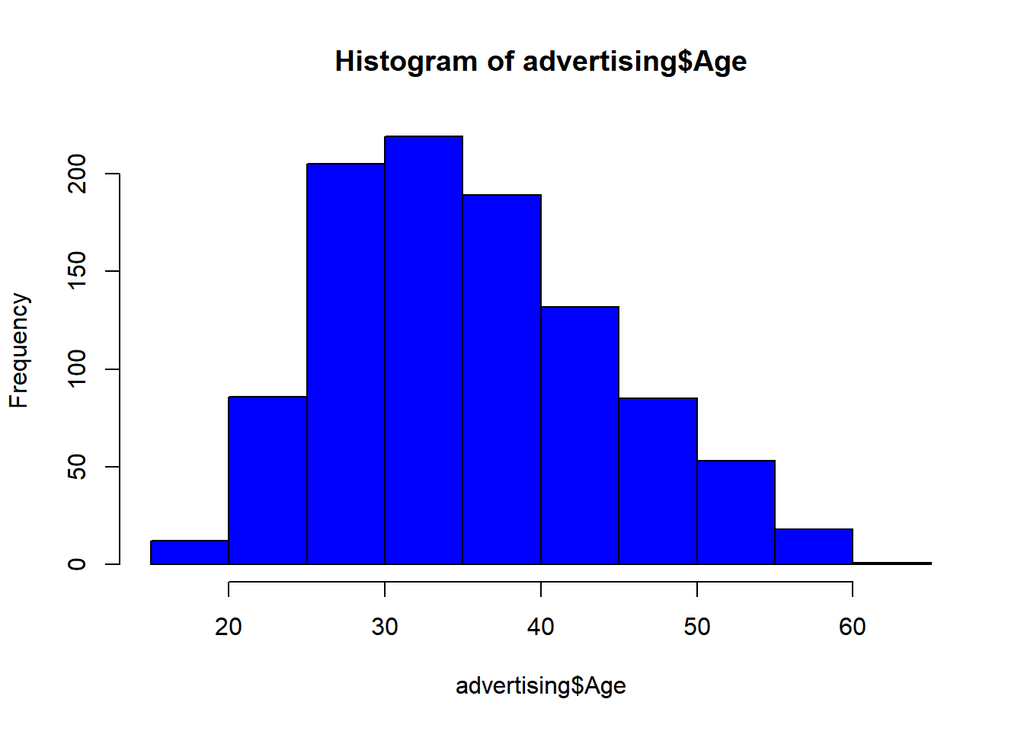

```r
hist(advertising$Age,col=c("blue"))
```

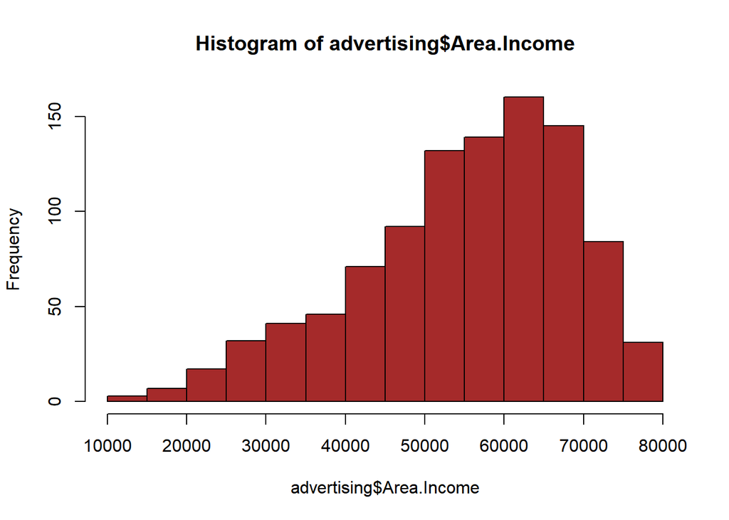

```r
#frequency histogram to show the income distribution
hist(advertising$Area.Income,col = "brown")
```

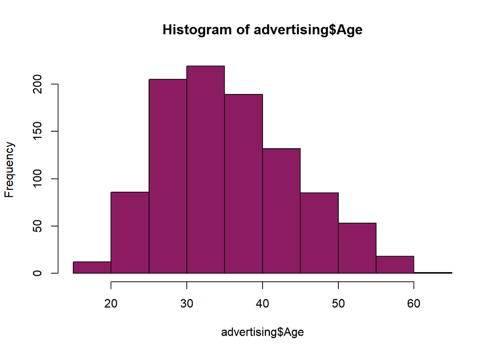

```r
#histogram to show the Age distribution
hist(advertising$Age,col=("maroon4"))
```

##Bivariate analysis

```r
head(advertising)
```

```
##   Daily.Time.Spent.on.Site Age Area.Income Daily.Internet.Usage
## 1                    68.95  35    61833.90               256.09
## 2                    80.23  31    68441.85               193.77
## 3                    69.47  26    59785.94               236.50
## 4                    74.15  29    54806.18               245.89
## 5                    68.37  35    73889.99               225.58
## 6                    59.99  23    59761.56               226.74
##                           Ad.Topic.Line           City Male    Country
## 1    Cloned 5thgeneration orchestration    Wrightburgh    0    Tunisia
## 2    Monitored national standardization      West Jodi    1      Nauru
## 3      Organic bottom-line service-desk       Davidton    0 San Marino
## 4 Triple-buffered reciprocal time-frame West Terrifurt    1      Italy
## 5         Robust logistical utilization   South Manuel    0    Iceland
## 6       Sharable client-driven software      Jamieberg    1     Norway
##             Timestamp Clicked.on.Ad
## 1 2016-03-27 00:53:11             0
## 2 2016-04-04 01:39:02             0
## 3 2016-03-13 20:35:42             0
## 4 2016-01-10 02:31:19             0
## 5 2016-06-03 03:36:18             0
## 6 2016-05-19 14:30:17             0
```

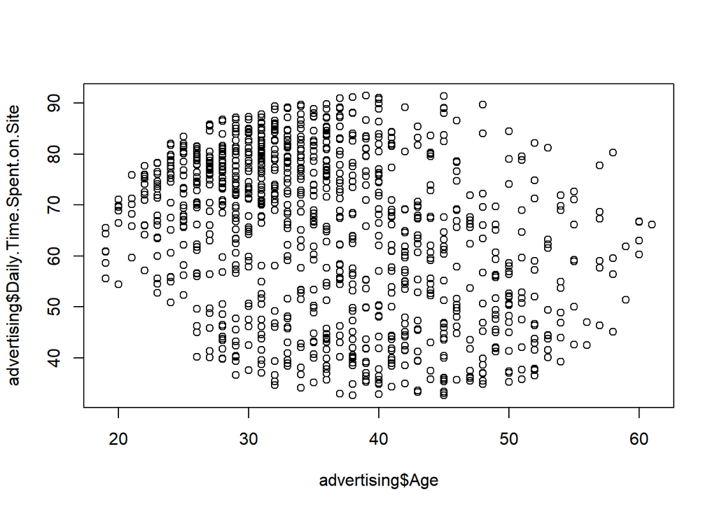

```r
#scatter plot to show the relationship between age and Daily time spend on site
plot(advertising$Age, advertising$Daily.Time.Spent.on.Site )
```

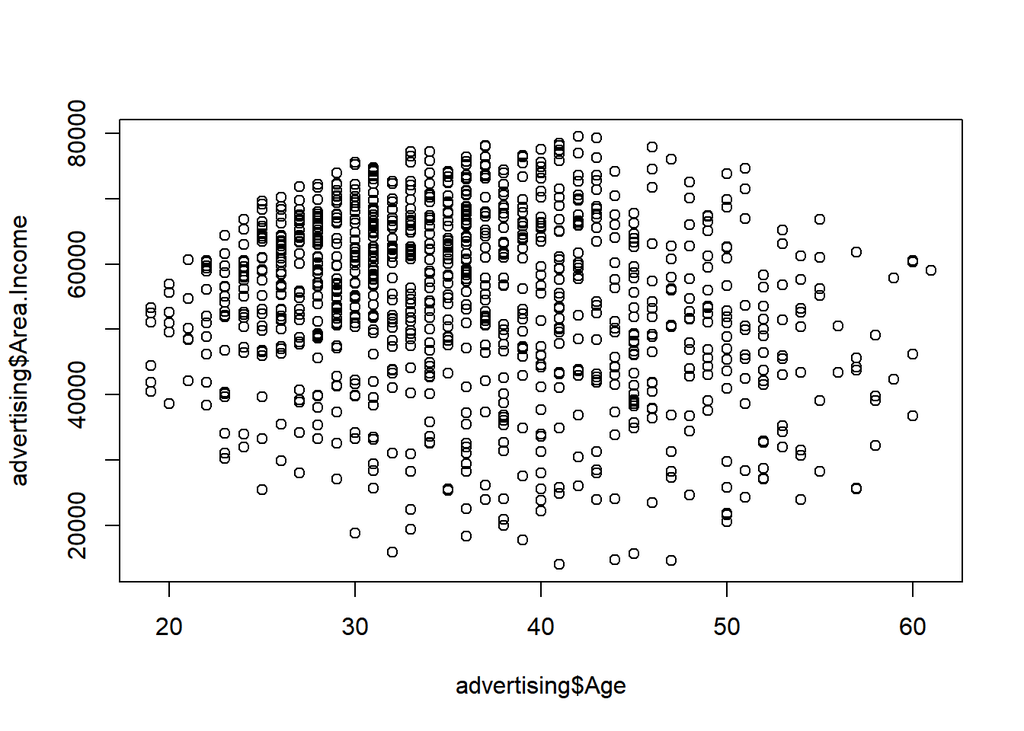

```r
#scater plot to show the relationship between Age and area income
plot(advertising$Age, advertising$Area.Income )
```

from the plot majority of the people with the wealth lie around the age of 45 and below

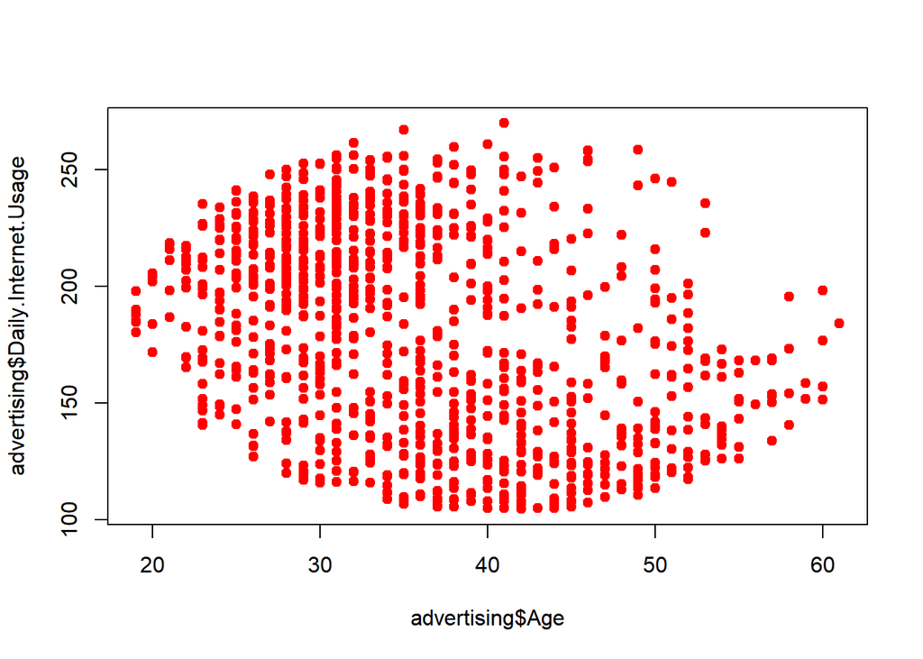

```r
#scater plot to show the relationship between Age and Daily.iinternet usage

plot(advertising$Age, advertising$Daily.Internet.Usage, pch = 19, col = "red")
```

There is great internet usage between the age 25 to 35 where it then reduces as the age increases

```r
adverts <- subset (advertising, select = -c(Ad.Topic.Line,City,Country,Timestamp))
```

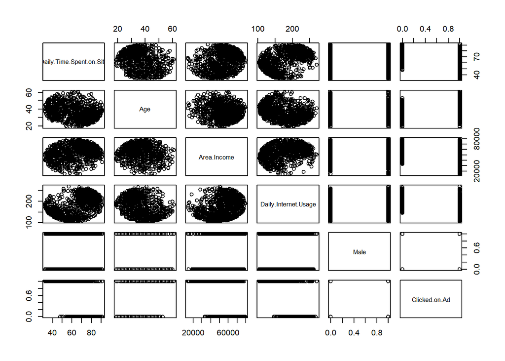

```r
#plotting a scatter plot for the adverts dataset
plot(adverts)
```

```r
res2 <-cor.test(advertising$Age, advertising$Daily.Internet.Usage,  method = "spearman")
res2
```

```
##
##  Spearman's rank correlation rho
##
## data:  advertising$Age and advertising$Daily.Internet.Usage
## S = 228477096, p-value < 2.2e-16
## alternative hypothesis: true rho is not equal to 0
## sample estimates:
##        rho
## -0.3708639
```

```r
res2 <-cor.test(advertising$Age, advertising$Clicked.on.Ad,  method = "spearman")
res2
```

```
##
##  Spearman's rank correlation rho
##
## data:  advertising$Age and advertising$Clicked.on.Ad
## S = 85610359, p-value < 2.2e-16
## alternative hypothesis: true rho is not equal to 0
## sample estimates:
##       rho
## 0.4863373
```

```r
library(corrplot)
mydata.rcorr = cor(as.matrix(adverts))
mydata.rcorr
```

```
##                          Daily.Time.Spent.on.Site         Age  Area.Income
## Daily.Time.Spent.on.Site               1.00000000 -0.33151334  0.310954413
## Age                                   -0.33151334  1.00000000 -0.182604955
## Area.Income                            0.31095441 -0.18260496  1.000000000
## Daily.Internet.Usage                   0.51865848 -0.36720856  0.337495533
## Male                                  -0.01895085 -0.02104406  0.001322359
## Clicked.on.Ad                         -0.74811656  0.49253127 -0.476254628
##                          Daily.Internet.Usage         Male Clicked.on.Ad
## Daily.Time.Spent.on.Site           0.51865848 -0.018950855   -0.74811656
## Age                               -0.36720856 -0.021044064    0.49253127
## Area.Income                        0.33749553  0.001322359   -0.47625463
## Daily.Internet.Usage               1.00000000  0.028012326   -0.78653918
## Male                               0.02801233  1.000000000   -0.03802747
## Clicked.on.Ad                     -0.78653918 -0.038027466    1.00000000
```

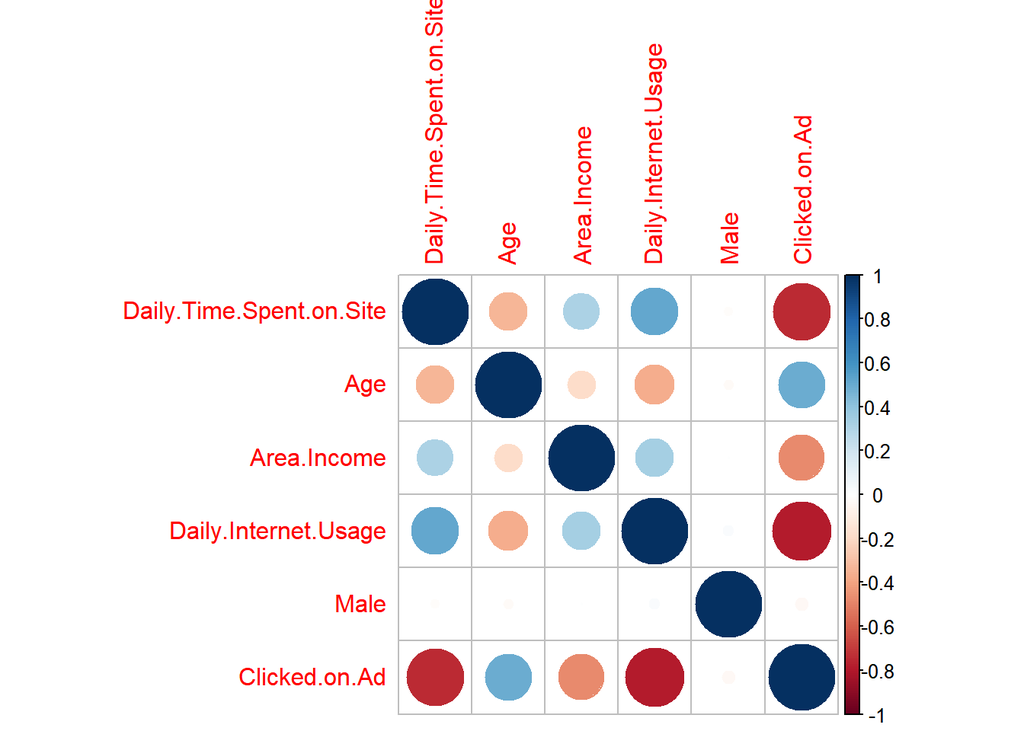

```r
corrplot(mydata.rcorr)
```

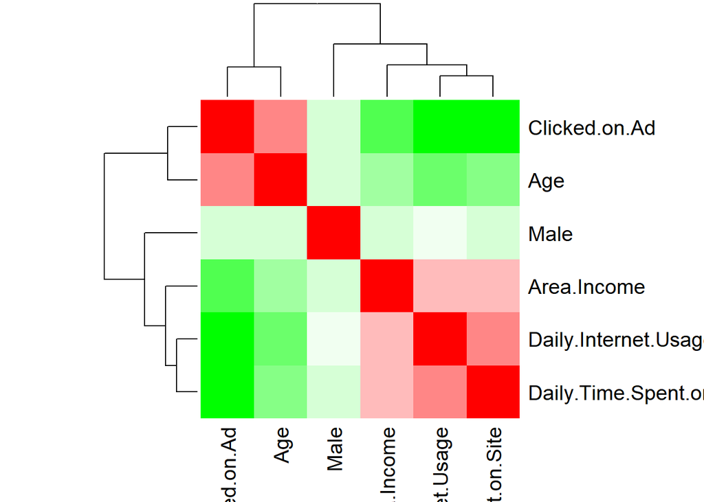

```r
palette = colorRampPalette(c("green", "white", "red")) (20)
heatmap(x = mydata.rcorr, col = palette, symm = TRUE)
```

```r
library("PerformanceAnalytics")
```

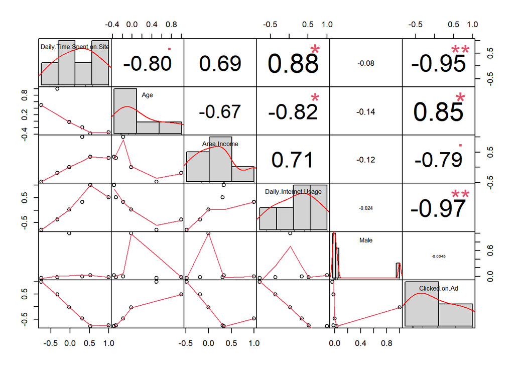

```r
chart.Correlation(mydata.rcorr, histogram=TRUE, pch=19)
```